# CPI_ARIMA

Matthew Colao

2025-04-02

# Overview -

Consumer Price Index for All Urban Consumers: Information Technology, Hardware and Services in U.S. City Average.  
Ranges from December 1988 to February 2025.  
Tracks the price change of IT related goods and services over time.

## Sections

1. Our Libraries & Data.
2. Perform ARIMA on your time series.
3. Explain the output.
4. Run Residual Analysis
5. Perform and Plot the forecast for the next five periods
6. Show the accuracy of your ARIMA model

# Our Libraries & Data

```r
library(fpp)
library(fpp2)
library(forecast)

cpi_it <- read.csv("/Users/mattcolao/Downloads/CPI_feb_nonseasonal.csv")
cpi_ts <- ts(cpi_it[,2], start=c(1988,12), frequency = 12)
```

# Perform ARIMA on your time series.

```r
# Number for seasonal stationary time series
nsdiffs(cpi_ts)
```

```
## [1] 0
```

```r
# Number for stationary time series
ndiffs(cpi_ts)
```

```
## [1] 2
```

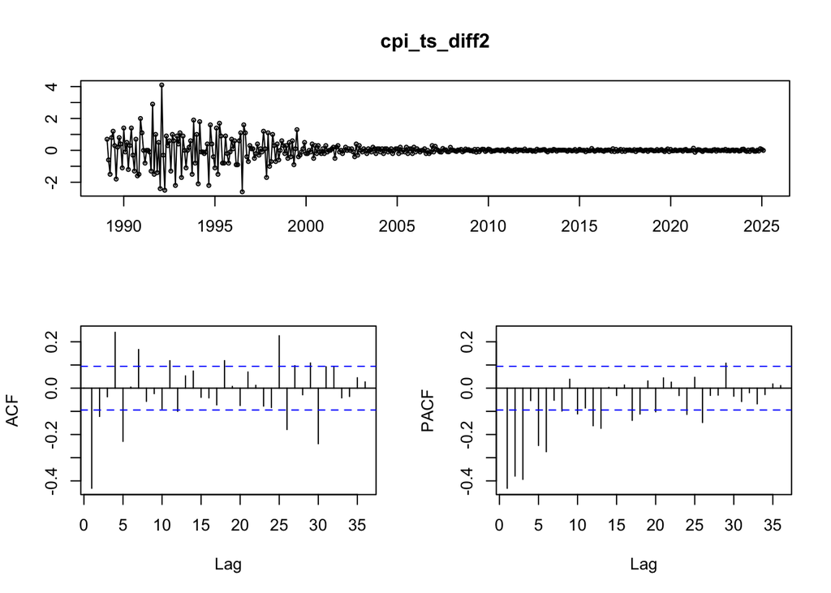

```r
# Acf, Pacf, and plot with differencing of 2
cpi_ts_diff2 <- diff(cpi_ts, differences = 2)
tsdisplay(cpi_ts_diff2)
```

```r
arima_cpi <- auto.arima(cpi_ts, trace = TRUE, stepwise = FALSE, seasonal = TRUE)
```

```
##
##  Fitting models using approximations to speed things up...
##
##  ARIMA(0,2,0)                               : 797.4054
##  ARIMA(0,2,0)(0,0,1)[12]                    : 794.1669
##  ARIMA(0,2,0)(0,0,2)[12]                    : 793.7573
##  ARIMA(0,2,0)(1,0,0)[12]                    : 771.2195
##  ARIMA(0,2,0)(1,0,1)[12]                    : 768.8939
##  ARIMA(0,2,0)(1,0,2)[12]                    : 770.6125
##  ARIMA(0,2,0)(2,0,0)[12]                    : 726.5662
##  ARIMA(0,2,0)(2,0,1)[12]                    : 708.7061
##  ARIMA(0,2,0)(2,0,2)[12]                    : 705.4161
##  ARIMA(0,2,1)                               : 520.0407
##  ARIMA(0,2,1)(0,0,1)[12]                    : 521.6776
##  ARIMA(0,2,1)(0,0,2)[12]                    : 522.5635
##  ARIMA(0,2,1)(1,0,0)[12]                    : 503.0504
##  ARIMA(0,2,1)(1,0,1)[12]                    : 503.9646
##  ARIMA(0,2,1)(1,0,2)[12]                    : 505.4481
##  ARIMA(0,2,1)(2,0,0)[12]                    : 438.7941
##  ARIMA(0,2,1)(2,0,1)[12]                    : 440.4467
##  ARIMA(0,2,1)(2,0,2)[12]                    : 438.5778
##  ARIMA(0,2,2)                               : 522.0587
##  ARIMA(0,2,2)(0,0,1)[12]                    : 523.7147
##  ARIMA(0,2,2)(0,0,2)[12]                    : 524.6104
##  ARIMA(0,2,2)(1,0,0)[12]                    : 504.7173
##  ARIMA(0,2,2)(1,0,1)[12]                    : 505.5182
##  ARIMA(0,2,2)(1,0,2)[12]                    : 506.9322
##  ARIMA(0,2,2)(2,0,0)[12]                    : 435.1016
##  ARIMA(0,2,2)(2,0,1)[12]                    : 437.1252
##  ARIMA(0,2,3)                               : 516.5418
##  ARIMA(0,2,3)(0,0,1)[12]                    : 517.8795
##  ARIMA(0,2,3)(0,0,2)[12]                    : 518.0388
##  ARIMA(0,2,3)(1,0,0)[12]                    : 499.5362
##  ARIMA(0,2,3)(1,0,1)[12]                    : 500.3082
##  ARIMA(0,2,3)(2,0,0)[12]                    : 431.7196
##  ARIMA(0,2,4)                               : 515.9398
##  ARIMA(0,2,4)(0,0,1)[12]                    : 516.1868
##  ARIMA(0,2,4)(1,0,0)[12]                    : 497.8399
##  ARIMA(0,2,5)                               : 502.3477
##  ARIMA(1,2,0)                               : 709.3079
```

[output cut: 51 more lines]

```
##  ARIMA(3,2,1)(0,0,1)[12]                    : 538.7456
##  ARIMA(3,2,1)(1,0,0)[12]                    : 486.7494
##  ARIMA(3,2,2)                               : 520.3704
##  ARIMA(4,2,0)                               : 564.6997
##  ARIMA(4,2,0)(0,0,1)[12]                    : 566.6754
##  ARIMA(4,2,0)(1,0,0)[12]                    : 554.6521
##  ARIMA(4,2,1)                               : 518.0471
##  ARIMA(5,2,0)                               : 539.208
##
##  Now re-fitting the best model(s) without approximations...
##
##
##
##
##  Best model: ARIMA(2,2,1)(2,0,0)[12]
```

```r
arima_cpi
```

```
## Series: cpi_ts
## ARIMA(2,2,1)(2,0,0)[12]
##
## Coefficients:
##           ar1     ar2      ma1     sar1     sar2
##       -0.0117  -0.167  -0.9254  -0.0507  -0.0943
## s.e.   0.0500   0.050   0.0183   0.0505   0.0543
##
## sigma^2 = 0.1882:  log likelihood = -251.48
## AIC=514.96   AICc=515.16   BIC=539.39
```

# Explain the Output.

ARIMA(2,2,1) is the nonseasonal component that has 2 AR terms and 1 MA term. All the coefficients for it are in reasonable range. ARIMA(2,0,0) is the seasonal component that has 2 AR terms and 0 for the rest. The coefficients are also in a reasonable range. Sigma^2 is also reasonable so we can move to the analyzing the residuals.

# Run Residual Analysis

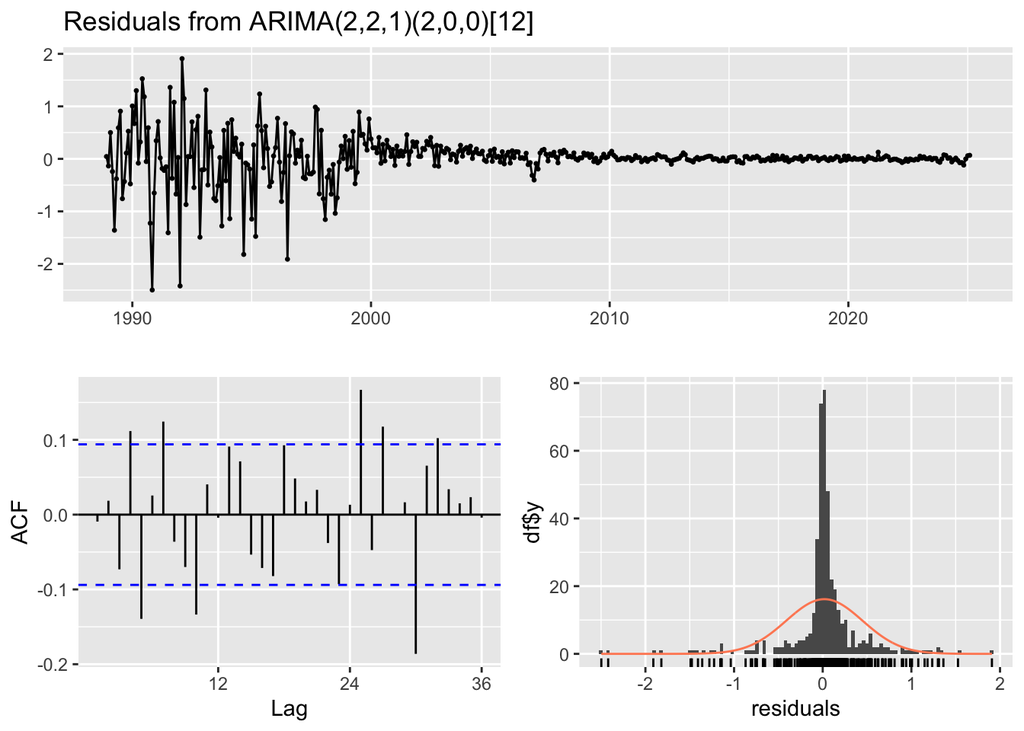

```
##
##  Ljung-Box test
##
## data:  Residuals from ARIMA(2,2,1)(2,0,0)[12]
## Q* = 58.349, df = 19, p-value = 7.039e-06
##
## Model df: 5.   Total lags used: 24
```

```r
checkresiduals(arima_cpi)
```

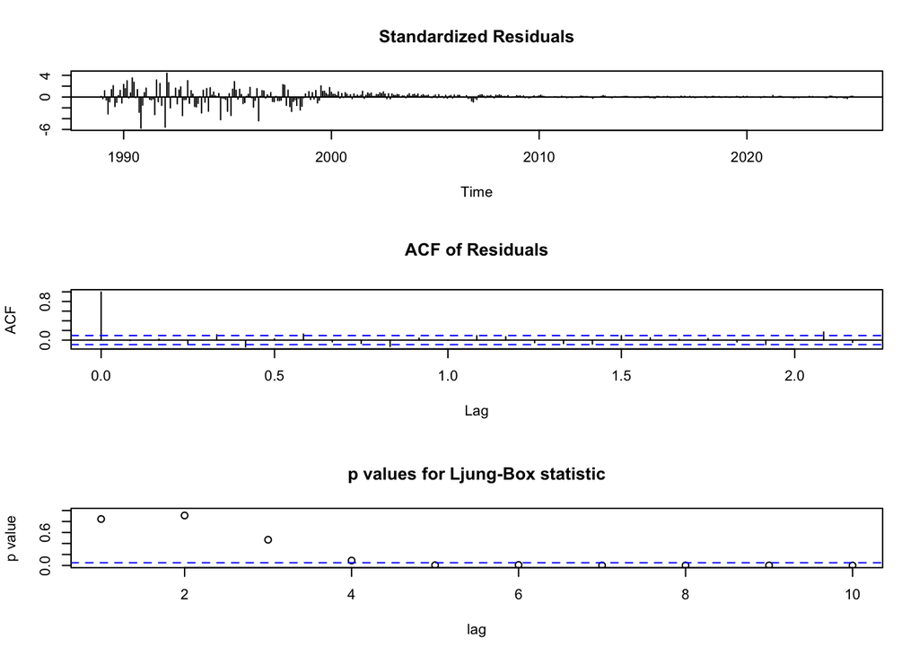

```r
tsdiag(arima_cpi,gof.lag = 10)
```

```r
shapiro.test(residuals(arima_cpi))
```

```
##
##  Shapiro-Wilk normality test
##
## data:  residuals(arima_cpi)
## W = 0.76684, p-value < 2.2e-16
```

The residuals conclude that the model fails to capture some aspects of the data, as seen by the Acf with spikes outside of the band of significance and also further proven by the Ljung-Box test and the Shapiro-Wilk test. The Ljung-Box test has too low a p-value, meaning there is autocorellation present in the residuals. The Shapiro-Wilk test also has a very low p-value, meaning the residuals are not normally distributed as they should be. More tweaking and modifying of the ARIMA model or the date itself is needed.

# Perform and Plot the forecast for the next five periods

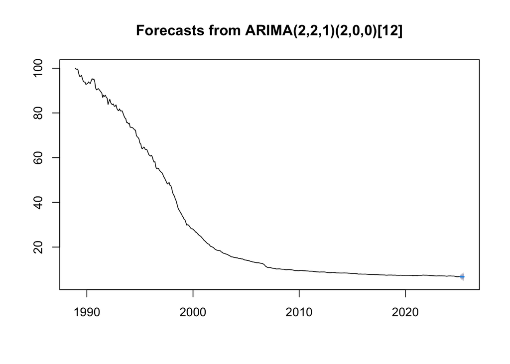

```r
forecast_arima <- forecast(arima_cpi, h=5)
plot(forecast_arima)
```

```r
forecast_arima
```

```
##          Point Forecast    Lo 80    Hi 80    Lo 95    Hi 95
## Mar 2025       6.772254 6.216339 7.328169 5.922056 7.622452
## Apr 2025       6.745145 5.933869 7.556420 5.504405 7.985884
## May 2025       6.733105 5.759056 7.707153 5.243426 8.222783
## Jun 2025       6.716715 5.585461 7.847968 4.986612 8.446817
## Jul 2025       6.699489 5.407078 7.991899 4.722917 8.676060
```

# Show the accuracy of your ARIMA model

```r
accuracy(forecast_arima)
```

```
##                      ME      RMSE       MAE      MPE      MAPE       MASE
## Training set 0.01874906 0.4302782 0.2255295 0.150721 0.6695843 0.08799108
##                      ACF1
## Training set -0.009315556
```

The model performs better than the baseline naive model and captures most of the autocorrelation. However, it could be made more accurate.